# act_report

## Report: act_report

- Create a **250-word-minimum written report** called "act_report.pdf" or "act_report.html" that communicates the insights and displays the visualization(s) produced from your wrangled data. This is to be framed as an external document, like a blog post or magazine article, for example.

## WeRateDogs: One Firm's Adoption of Data Analytics Tools for Better Decision-Making

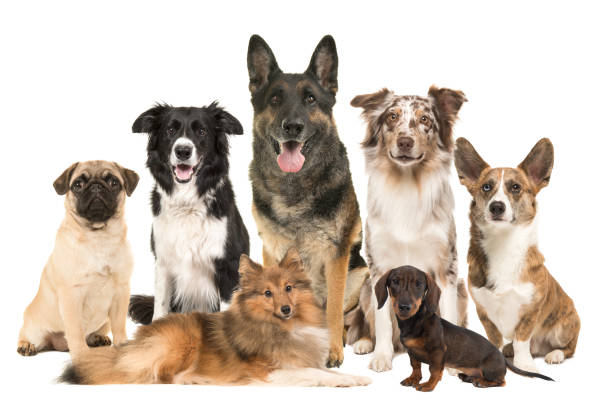

### Introduction

Dogs are considered one of the core animals that people keep as pets, and in other places, are core in meeting human related needs, e.g., as huntng dogs. For WeRateDogs, taking an intitative in understanding how different users rate dogs is core in actively learning more about the pets, and offer useful insights that can help improve personal and corporate decision-making. The technology world is diverse, and with the rise of social media platforms, WeRateDogs relied on tweets and associated interactions as the basis in meeting the firms rating and insights goals.

### WeRateDogs: Business Problem and Data Overview

Data collection is just one stage in the data analytics process. And for WeRateDogs, the need in having sufficient and quality data is essential towards supporting better insights both for short and long-term decisions. For WeRateDogs, having a proper dataset is core as it can help in making better inferences. As the basis in offering better insights, the next sections provides an overview of the core findings, and the specificinsights seen from the data analysis on WeRateDogs.

### Core Data Findings

#### Twitter for iPhone Takes Lead

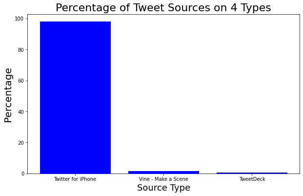

This information is useful, which also helps infer that most of the public engaged with the platform, and taking active measures in rating their dogs were also iPhone users. Moreover, with the WeRateDogs dataset also providing information on dog rating accuracy, it can also help make conclusions on how accurate iPhone users and most persons are better skilled in rating dogs.

#### An Amazing 70% + in Correct Dog Breed Image Prediction on Three(3) Aspects

Accuracy and Efficiency are core elements that when realized, can help improve the subsequent decisions made within business scope and personal endeavours. In the WeRateDogs analysis, of the three (3) rating correctness for dogs, an over 70% correctness score was identfied for p1_dog, p2_dog and p_dog in the image prediction. Making conclusions is useful, and with more accuracy and efficieny in correctly identifying and predicting dog breeds, the information hence becomes essential for use later, both for short and long-term decision-making

As shown in the image below above, across the three (3) rating aspects, the proportion of correct predictions are over 50%, i.e., p1_dog with 73.83%, p2_dog with 74.84 and finally p3_dog with 72.24%

The below visualization shows the findings outlook for p1_dog

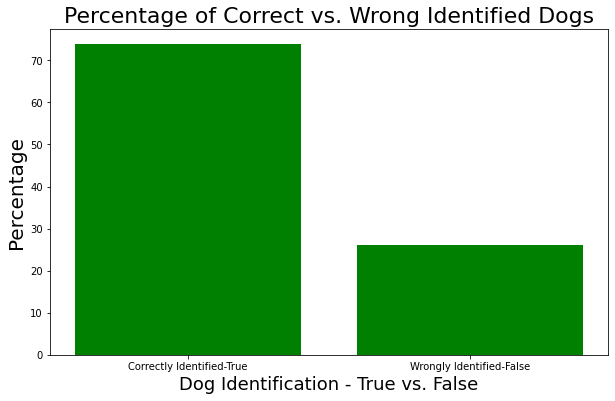

#### Pupper Takes the Lead as the most common Dog Satge

In the WeRateDogs dataset, one of the core aspects was on dog types, which was sub-divided as either, pupper, doggo, puppo and floofer. With the complete analysis, it is evident that of all the pre-defined types, most of the users and predicted dos were in the Pupper, having the largest prorpotion. This is as shown below in the tabulated summary

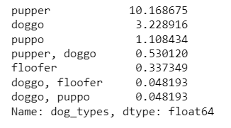

### Conclusion

The adoption of data analytics is core in supplementing decision-making, allowing the indepth examination of collected data, and applying useful tools to find meaning. Of the three tweet sources, Twitter for iPhone was the most used, and on dog types, the pupper emerged as the most identfied dog stage. Overall, for the image predictions, it is evident that over 70% of the made predictios were correct, depicting the accuracy level and efficiency in the process. Using this and additional infomation, it hence becomes fundamental in supporting subsequent positive decisions.

For WeRateDogs, the multiple data collected acted as the basis in getting more insights on data, essential in knowing more about the dog owners and also their use of online platforms. In ensuring sufficient conclusions, using Python analytics and data wrangking techniques is core in having a proper dataset for decision-making. For WeRateDogs, this is evident in the sampled data success in correctly rating pre-identified dogs.